# Trump vs Staff Tweets with H2O

Erin LeDell

11/2/2016

## Source

This is an adaptation of David Robinson’s popular [sentiment analysis of Trumps tweets](http://varianceexplained.org/r/trump-tweets/).

## The Trump Tweets dataset

The tweets were acquired by David Robinson using the [twitteR](https://cran.r-project.org/web/packages/twitteR/index.html) package and the Twitter API, but for convenience, he has provided the data here:

```r
load(url("http://varianceexplained.org/files/trump_tweets_df.rda"))
str(trump_tweets_df)
```

```
## Classes 'tbl_df', 'tbl' and 'data.frame':    1512 obs. of  16 variables:
##  $ text         : chr  "My economic policy speech will be carried live at 12:15 P.M. Enjoy!" "Join me in Fayetteville, North Carolina tomorrow evening at 6pm. Tickets now available at: https://t.co/Z80d4MYIg8" "#ICYMI: \"Will Media Apologize to Trump?\" https://t.co/ia7rKBmioA" "Michael Morell, t…
##  $ favorited    : logi  FALSE FALSE FALSE FALSE FALSE FALSE ...
##  $ favoriteCount: num  9214 6981 15724 19837 34051 ...
##  $ replyToSN    : chr  NA NA NA NA ...
##  $ created      : POSIXct, format: "2016-08-08 15:20:44" "2016-08-08 13:28:20" ...
##  $ truncated    : logi  FALSE FALSE FALSE FALSE FALSE FALSE ...
##  $ replyToSID   : logi  NA NA NA NA NA NA ...
##  $ id           : chr  "762669882571980801" "762641595439190016" "762439658911338496" "762425371874557952" ...
##  $ replyToUID   : chr  NA NA NA NA ...
##  $ statusSource : chr  "<a href=\"http://twitter.com/download/android\" rel=\"nofollow\">Twitter for Android</a>" "<a href=\"http://twitter.com/download/iphone\" rel=\"nofollow\">Twitter for iPhone</a>" "<a href=\"http://twitter.com/download/iphone\" rel=\"nofollow\">Twitter for iPhone</a>" "<a h…
##  $ screenName   : chr  "realDonaldTrump" "realDonaldTrump" "realDonaldTrump" "realDonaldTrump" ...
##  $ retweetCount : num  3107 2390 6691 6402 11717 ...
##  $ isRetweet    : logi  FALSE FALSE FALSE FALSE FALSE FALSE ...
##  $ retweeted    : logi  FALSE FALSE FALSE FALSE FALSE FALSE ...
##  $ longitude    : chr  NA NA NA NA ...
##  $ latitude     : chr  NA NA NA NA ...
```

We observe that there are 1512 tweets (rows) and 16 variables.

## Munge the data

It is known that Trump uses an Android device and it appears as if his staff typically tweets from an iPhone. Therefore, this metatdata serves as an author identifier.

Here we extract the terms, “iPhone” and “Android” from the `statusSource` column:

```r
#install.packages(c("dplyr", "purrr", "tidyr", "lubridate", "scales", "ggplot2", "tidytext"))
library(dplyr)
library(purrr)
library(tidyr)
```

**Note:** The order in which you load the packages actually *does* matter (and you will run into an error if they are loaded in the wrong order), so it’s best to clear your R environment and load the packages as directed in the script.

We will create a new, simplified, data frame called `tweets` with the following columsn: “id”, “source”, “text” and “created”. The “source” column contains just the terms, “iPhone” and “Android”.

```r
tweets <- trump_tweets_df %>%
  select(id, statusSource, text, created) %>%
  extract(statusSource, "source", "Twitter for (.*?)<") %>%
  filter(source %in% c("iPhone", "Android"))
```

In the new data frame, there are only 1390 tweets since we filtered to only rows which contained a source (Android vs iPhone). Using the `table()` function, we can easily count the number of tweets from Android vs iPhone:

```r
dim(tweets)
```

```
## [1] 1390    4
```

```r
table(tweets$source)
```

```
##
## Android  iPhone
##     762     628
```

### Remove stopwords

Use the tidytext package to clean up the text a bit:

```r
library(stringr)
library(tidytext)

reg <- "([^A-Za-z\\d#@']|'(?![A-Za-z\\d#@]))"
tweet_words <- tweets %>%
  filter(!str_detect(text, '^"')) %>%
  mutate(text = str_replace_all(text, "https://t.co/[A-Za-z\\d]+|&amp;", "")) %>%
  unnest_tokens(word, text, token = "regex", pattern = reg) %>%
  filter(!word %in% stop_words$word,
         str_detect(word, "[a-z]"))

tweet_words
```

```
## # A tibble: 8,753 × 4
##                    id source             created                   word
##                 <chr>  <chr>              <dttm>                  <chr>
## 1  676494179216805888 iPhone 2015-12-14 20:09:15                 record
## 2  676494179216805888 iPhone 2015-12-14 20:09:15                 health
## 3  676494179216805888 iPhone 2015-12-14 20:09:15 #makeamericagreatagain
## 4  676494179216805888 iPhone 2015-12-14 20:09:15             #trump2016
## 5  676509769562251264 iPhone 2015-12-14 21:11:12               accolade
## 6  676509769562251264 iPhone 2015-12-14 21:11:12             @trumpgolf
## 7  676509769562251264 iPhone 2015-12-14 21:11:12                 highly
## 8  676509769562251264 iPhone 2015-12-14 21:11:12              respected
## 9  676509769562251264 iPhone 2015-12-14 21:11:12                   golf
## 10 676509769562251264 iPhone 2015-12-14 21:11:12                odyssey
## # ... with 8,743 more rows
```

### Wordclouds!

[figure not shown]

```r
library(wordcloud, quietly = TRUE)

tweet_words %>%
  count(word) %>%
  with(wordcloud(word, n, max.words = 70, color = "purple"))
```

### Term-Frequency Inverse Document Frequency (tf-idf)

Here we’ll create a [Document-Term Matrix (DTM)](https://en.wikipedia.org/wiki/Document-term_matrix) to prepare the data for training an classifier. In a document-term matrix, rows correspond to documents in the collection and columns correspond to terms. There are various schemes for determining the value that each entry in the matrix should take. One such scheme is [tf-idf](https://en.wikipedia.org/wiki/Tf%E2%80%93idf).

The TF-IDF code is borrowed from the excellent tutorial, [“Term Frequency and Inverse Document Frequency (tf-idf) Using Tidy Data Principles”](https://cran.r-project.org/web/packages/tidytext/vignettes/tf_idf.html) by Julia Silge and David Robinson.

#### What is tf-idf?

Tf-idf stands for “term frequency-inverse document frequency”, and the “tf-idf weight”" is a weight often used in information retrieval and text mining. This weight is a statistical measure used to evaluate how important a word is to a document in a collection or corpus.

Typically, the tf-idf weight is composed by two terms: the first computes the normalized Term Frequency (TF), aka. the number of times a word appears in a document, divided by the total number of words in that document; the second term is the Inverse Document Frequency (IDF), computed as the logarithm of the number of the documents in the corpus divided by the number of documents where the specific term appears.

- TF: Term Frequency, which measures how frequently a term occurs in a document. Since every document is different in length, it is possible that a term would appear much more times in long documents than shorter ones. Thus, the term frequency is often divided by the document length (aka. the total number of terms in the document) as a way of normalization:

```
    TF(t) = (Number of times term t appears in a document) / (Total number of terms in the document)
```

- IDF: Inverse Document Frequency, which measures how important a term is. While computing TF, all terms are considered equally important. However it is known that certain terms, such as “is”, “of”, and “that”, may appear a lot of times but have little importance. Thus we need to weigh down the frequent terms while scale up the rare ones, by computing the following:

```
    IDF(t) = log_e(Total number of documents / Number of documents with term t in it)
```

#### Compute tf-idf weights

The first step is counting the number of times that a word appears in a single document (in this case a “document” is a tweet).

```r
tweet_word_counts <- tweet_words[, c("word", "id")] %>% count(id, word)
tweet_word_counts
```

```
## Source: local data frame [8,592 x 3]
## Groups: id [?]
##
##                    id                   word     n
##                 <chr>                  <chr> <int>
## 1  676494179216805888 #makeamericagreatagain     1
## 2  676494179216805888             #trump2016     1
## 3  676494179216805888                 health     1
## 4  676494179216805888                 record     1
## 5  676509769562251264            @trumpdoral     1
## 6  676509769562251264             @trumpgolf     1
## 7  676509769562251264               accolade     1
## 8  676509769562251264                awarded     1
## 9  676509769562251264                   blue     1
## 10 676509769562251264                   golf     1
## # ... with 8,582 more rows
```

Next, we will count the total number of words in each tweet.

```r
total_words <- tweet_word_counts %>%
  group_by(id) %>%
  summarize(total = sum(n))
total_words
```

```
## # A tibble: 1,172 × 2
##                    id total
##                 <chr> <int>
## 1  676494179216805888     4
## 2  676509769562251264    11
## 3  680496083072593920     8
## 4  680503951440121856     7
## 5  680505672476262400     7
## 6  680734915718176768     9
## 7  682764544402440192     1
## 8  682792967736848385     1
## 9  682805320217980929     4
## 10 685490467329425408    12
## # ... with 1,162 more rows
```

Join these two tables together as follows:

```r
tweet_word_counts <- left_join(tweet_word_counts, total_words)
tweet_word_counts
```

```
## Source: local data frame [8,592 x 4]
## Groups: id [?]
##
##                    id                   word     n total
##                 <chr>                  <chr> <int> <int>
## 1  676494179216805888 #makeamericagreatagain     1     4
## 2  676494179216805888             #trump2016     1     4
## 3  676494179216805888                 health     1     4
## 4  676494179216805888                 record     1     4
## 5  676509769562251264            @trumpdoral     1    11
## 6  676509769562251264             @trumpgolf     1    11
## 7  676509769562251264               accolade     1    11
## 8  676509769562251264                awarded     1    11
## 9  676509769562251264                   blue     1    11
## 10 676509769562251264                   golf     1    11
## # ... with 8,582 more rows
```

Finally we can use the handy `bind_tf_idf()` function from the tidytext package to add the “tf”, “idf” and “tf_idf” columns to the data frame.

```r
tweet_word_counts <- tweet_word_counts %>%
  bind_tf_idf(word, id, n)
tweet_word_counts
```

```
## Source: local data frame [8,592 x 7]
## Groups: id [?]
##
##                    id                   word     n total         tf
##                 <chr>                  <chr> <int> <int>      <dbl>
## 1  676494179216805888 #makeamericagreatagain     1     4 0.25000000
## 2  676494179216805888             #trump2016     1     4 0.25000000
## 3  676494179216805888                 health     1     4 0.25000000
## 4  676494179216805888                 record     1     4 0.25000000
## 5  676509769562251264            @trumpdoral     1    11 0.09090909
## 6  676509769562251264             @trumpgolf     1    11 0.09090909
## 7  676509769562251264               accolade     1    11 0.09090909
## 8  676509769562251264                awarded     1    11 0.09090909
## 9  676509769562251264                   blue     1    11 0.09090909
## 10 676509769562251264                   golf     1    11 0.09090909
## # ... with 8,582 more rows, and 2 more variables: idf <dbl>, tf_idf <dbl>
```

Let’s sort by the words with the greatest TF-IDF value:

```r
tweet_word_counts %>%
  select(-total) %>%
  arrange(desc(tf_idf))
```

```
## Source: local data frame [8,592 x 6]
## Groups: id [1,172]
##
##                    id                  word     n    tf      idf   tf_idf
##                 <chr>                 <chr> <int> <dbl>    <dbl>    <dbl>
## 1  682792967736848385  #happynewyearamerica     1     1 7.066467 7.066467
## 2  743947386720923648             @dallaspd     1     1 7.066467 7.066467
## 3  703326546686115840                 sweat     1     1 6.373320 6.373320
## 4  761653875413618689 #makeamericasafeagain     1     1 5.967855 5.967855
## 5  708183163969740800            #gopdebate     1     1 5.457029 5.457029
## 6  707225181513719808            @erictrump     1     1 5.274708 5.274708
## 7  682764544402440192                 happy     1     1 4.668572 4.668572
## 8  758030957530255360       #crookedhillary     1     1 4.233254 4.233254
## 9  758422125254471680       #crookedhillary     1     1 4.233254 4.233254
## 10 758802697763958784       #crookedhillary     1     1 4.233254 4.233254
## # ... with 8,582 more rows
```

#### Document-term Matrix

Now that we have the tf-idf weights computed, we can create the document-term matrix. This matrix becomes the training data for our machine learning task.

The `tidytext::cast_sparse()` function should work here, but we get an error.

```r
#library(devtools)
#install_github("juliasilge/tidytext")
#dtm <- cast_sparse_(tweet_word_counts, id, word, tf_idf)
```

So while we are waiting for that bug to be fixed, we can just create our own document-term matrix function that produces an H2O Frame.

```r
cast_dtm_h2o <- function(data, row_col, column_col, value_col = 1, sparse = FALSE) {
  # This function is a modified version of tidytext::cast_sparse_

  # ungroup the data
  data <- ungroup(data)
  data <- distinct_(data, row_col, column_col, .keep_all = TRUE)
  row_names <- data[[ row_col]]
  col_names <- data[[column_col]]
  if (is.numeric(value_col)) {
    values <- value_col
  } else {
    values <- data[[value_col]]
  }

  # if it's a factor, preserve ordering
  if (is.factor(row_names)) {
    row_u <- levels(row_names)
    i <- as.integer(row_names)
  } else {
    row_u <- unique(row_names)
    i <- match(row_names, row_u)
  }

  if (is.factor(col_names)) {
    col_u <- levels(col_names)
    j <- as.integer(col_names)
  } else {
    col_u <- unique(col_names)
    j <- match(col_names, col_u)
  }

  ret <- Matrix::sparseMatrix(i = i, j = j, x = values,
                              dimnames = list(row_u, col_u))

  if (!sparse) {
    # Convert the sparse matrix to an H2OFrame
    ret <- as.h2o(as.matrix(ret))
  }
  ret
}
```

```r
# Load H2O and start up a local H2O cluster
#install.packages("h2o")
library(h2o)
h2o.init(nthreads = -1)
```

```
##  Connection successful!
##
## R is connected to the H2O cluster:
##     H2O cluster uptime:         4 hours 7 minutes
##     H2O cluster version:        3.10.0.8
##     H2O cluster version age:    23 days
##     H2O cluster name:           H2O_started_from_R_me_erw683
##     H2O cluster total nodes:    1
##     H2O cluster total memory:   3.25 GB
##     H2O cluster total cores:    8
##     H2O cluster allowed cores:  8
##     H2O cluster healthy:        TRUE
##     H2O Connection ip:          localhost
##     H2O Connection port:        54321
##     H2O Connection proxy:       NA
##     R Version:                  R version 3.3.0 (2016-05-03)
```

Now that the H2O cluster is running, we can convert our data frame of tweets into a document-term H2O Frame.

```r
dtm <- cast_dtm_h2o(tweet_word_counts, "id", "word", "tf_idf")
dim(dtm)
```

```
## [1] 1172 2560
```

The last step in this data munging process is to append the response column (Android vs iPhone) to the training data frame, `dtm`.

The following will produce a data frame which contains just the 1172 unique ids that were in our `tweet_word_counts` frame, and their corresponding labels (Android vs iPhone).

```r
labels <- semi_join(tweets[,c("id", "source")],
                    tweet_word_counts[,c("id")],
                    by = "id")
```

Lastly, we will column-bind the response column onto our training H2O Frame, `dtm`.

```r
dtm <- h2o.cbind(dtm, as.h2o(labels$source))
names(dtm)[ncol(dtm)] <- "source"
dim(dtm)
```

```
## [1] 1172 2561
```

## Classify Tweets using H2O Machine Learning

Now that we have completed the “data munging” phase, we are ready to do some machine learning. Since we have a binary response column (Android vs iPhone), we will train a binary classification algorithm.

### Generalized Linear Model (GLM)

Let’s start with a GLM. We will use 5-fold cross-validation to evaluate the performance of our model.

```r
# Define the response variable and set of predictors
y <- "source"
x <- setdiff(names(dtm), y)

glm_fit1 <- h2o.glm(x = x,
                    y = y,
                    family = "binomial",
                    training_frame = dtm,
                    nfolds = 5)
```

We can look at all the H2O performance metrics by using the `h2o.performance()` function.

```r
h2o.performance(glm_fit1, xval = TRUE)
```

```
## H2OBinomialMetrics: glm
## ** Reported on cross-validation data. **
## ** 5-fold cross-validation on training data (Metrics computed for combined holdout predictions) **
##
## MSE:  0.1733885
## RMSE:  0.4163994
## LogLoss:  0.5196218
## Mean Per-Class Error:  0.2577379
## AUC:  0.8363998
## Gini:  0.6727996
## R^2:  0.3042397
## Null Deviance:  1621.772
## Residual Deviance:  1217.993
## AIC:  1683.993
##
## Confusion Matrix for F1-optimal threshold:
##         Android iPhone    Error       Rate
## Android     368    185 0.334539   =185/553
## iPhone      112    507 0.180937   =112/619
## Totals      480    692 0.253413  =297/1172
##
## Maximum Metrics: Maximum metrics at their respective thresholds
##                         metric threshold    value idx
## 1                       max f1  0.476779 0.773455 213
## 2                       max f2  0.192502 0.850887 370
## 3                 max f0point5  0.567030 0.833747 156
## 4                 max accuracy  0.517481 0.753413 186
## 5                max precision  0.996046 1.000000   0
## 6                   max recall  0.069790 1.000000 399
## 7              max specificity  0.996046 1.000000   0
## 8             max absolute_mcc  0.559209 0.567912 161
## 9   max min_per_class_accuracy  0.514544 0.752827 188
## 10 max mean_per_class_accuracy  0.559209 0.763208 161
##
## Gains/Lift Table: Extract with `h2o.gainsLift(<model>, <data>)` or `h2o.gainsLift(<model>, valid=<T/F>, xval=<T/F>)`
```

Since this is a binomial classification problem, we might be interested in evaluting the cross-validated AUC value:

```r
h2o.auc(glm_fit1, xval = TRUE)
```

```
## [1] 0.8363998
```

By default, H2O chooses the classfication threshold that maximies the F1 score. So if you are interested in inspecting the confusion matrix, keep that in mind. The threshold can also be manually specified by the user.

## Visualize Tweets

We can extract the time that the Tweet was made from the “created” column using the [lubridate](https://cran.r-project.org/web/packages/lubridate/index.html) package. This code snippet is taken right from David Robinson’s original blog post.

```r
library(lubridate, warn.conflicts = FALSE)
library(scales)
```

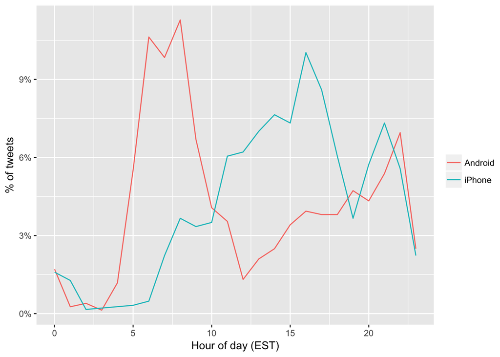

```r
library(ggplot2)

tweets %>%
  count(source, hour = hour(with_tz(created, "EST"))) %>%
  mutate(percent = n / sum(n)) %>%
  ggplot(aes(hour, percent, color = source)) +
  geom_line() +
  scale_y_continuous(labels = percent_format()) +
  labs(x = "Hour of day (EST)",
       y = "% of tweets",
       color = "")
```